# HighestPoint Operator

Author

Anonymous

Published

2026-04-07

# Overview / TLDR

For modeling the signed error on the **Y-axis**, we ran the following models:

- Lomax
- Exponential
- Weibull — this is the best-performing one.
- Log-Normal
- Gamma

For later fitting purposes, we also modeled the signed error on the **X-axis** to obtain hyper-priors.

# Set up

Read in data and relevant scales:

```r
task_df <- read_rds(here("data", "part1", "task.rds"))
participants <- read_rds(here("data", "part1", "participants.rds"))
exp1_x <- make_va_scale(data_min = -5, data_max = 5, px_min = 50, px_max = 585)
exp1_y <- make_va_scale(data_min = 0, data_max = 1, px_min = 410, px_max = 15)
```

Load data specific for this task:

```r
task2_df <- task_df %>%
  filter(task == "task2") %>%
  select(-slider.x, -slider.y) %>%
  mutate(
    data.ans.x = param.mu,
    data.ans.y = dsgt(
      param.mu,
      param.mu,
      param.sigma,
      param.lambda,
      param.p,
      param.q,
      mean.cent = FALSE
    ),
    data.left.grad = numDeriv::grad(
      dsgt,
      param.mu - 1,
      mu = param.mu,
      sigma = param.sigma,
      lambda = param.lambda,
      p = param.p,
      q = param.q,
      mean.cent = FALSE
    ),
    data.right.grad = numDeriv::grad(
      dsgt,
      param.mu + 1,
      mu = param.mu,
      sigma = param.sigma,
      lambda = param.lambda,
      p = param.p,
      q = param.q,
      mean.cent = FALSE
    ),
  ) %>%
  right_join(participants, by = join_by(participantId)) %>%
  # calculate things related to participants' selection
  mutate(
    va.resp.x = exp1_x$px_to_va(pixel.select.x, dist_to_screen, pixelToMM),
    va.resp.y = exp1_y$px_to_va(pixel.select.y, dist_to_screen, pixelToMM),
    va.ans.x = exp1_x$data_to_va(data.ans.x, dist_to_screen, pixelToMM),
    va.ans.y = exp1_y$data_to_va(data.ans.y, dist_to_screen, pixelToMM),
  ) %>%
  mutate(flat = (abs(data.left.grad) + abs(data.right.grad)) / 2)
```

```r
# Checking relations, focusing on the **Y** Axis

task2_df %>%
  mutate(error_va = va.resp.x - va.ans.x) %>%
  mutate(error_va = ifelse(error_va < tolerance, 0, error_va)) %>%
  ggplot(aes(x = error_va)) +
  geom_dots()

task2_df %>%
  ggplot(aes(y = va.ans.y - va.resp.y, x = dist_to_screen)) +
  geom_point(alpha = 0.5)

task2_df %>% ggplot(aes(x = va.ans.y - va.resp.y)) + geom_dots()
```

```r
# Checking relations, focusing on the **X** Axis:

task2_df %>% ggplot(aes(x = data.ans.x - data.select.x)) + geom_dots()

task2_df %>% ggplot(aes(x = va.resp.x - va.ans.x)) + geom_dots()

task2_df %>%
  ggplot(aes(x = va.resp.x - va.ans.x)) +
  geom_dots() +
  facet_wrap(~participantId)

task2_df %>%
  ggplot(aes(y = va.resp.x - va.ans.x, x = dist_to_screen)) +
  geom_point(alpha = 0.5)

task2_df %>%
  ggplot(aes(y = va.resp.x - va.ans.x, x = param.lambda)) +
  geom_point(alpha = 0.5) +
  labs(title = "Signed error on X-Axis against skewness")
```

# Error on Y

## Error on Y, Lomax distribution

[Wikipedia](https://en.wikipedia.org/wiki/Lomax_distribution). Note that `alpha` is shape and `lambda` is scale. This is the [stan reference](https://mc-stan.org/docs/functions-reference/positive_lower-bounded_distributions.html#pareto-type-2-distribution). Math model:

```r
# Define the Lomax family
lomax_family <- custom_family(
  "lomax",
  dpars = c("mu", "lambda", "alpha"), # parameters: lambda = scale, alpha = shape
  links = c("identity", "log", "log"), # log links ensure parameters are positive
  lb = c(-Inf, 0, 0), # lower bounds for both parameters
  type = "real"
)

# The Stan code for the Pareto log-likelihood function
# Note: Stan already has a built-in pareto_lpdf function
stan_funs <- "
  // Use the built-in pareto_type_2_lpdf function
  real lomax_lpdf(real y, real mu, real lambda, real alpha) {
    return pareto_type_2_lpdf(y | 0, lambda, alpha);
  }

  real lomax_rng(real mu, real lambda, real alpha) {
    return pareto_type_2_rng(0, lambda, alpha);
  }
"
```

Formula and posterior:

```
Formula and Posterior
```

```r
f <- bf(
  error.y ~ 0,
  mu ~ 0,
  lambda ~ (1 | participantId),
  alpha ~ (1 | participantId),
  family = lomax_family
)

p <- c(
  prior(normal(0, 1), class = Intercept, dpar = alpha),
  prior(cauchy(0, 1), class = sd, group = participantId, dpar = alpha, lb = 0),
  prior(normal(0, 1), class = Intercept, dpar = lambda),
  prior(cauchy(0, 1), class = sd, group = participantId, dpar = lambda, lb = 0)
)
```

Fit the model:

```r
model.y.lomax <- task2_df %>%
  mutate(error.y = abs(va.ans.y - va.resp.y)) %>%
  brm(
    formula = f,
    data = .,
    family = lomax_family,
    prior = p,
    stanvars = stanvar(scode = stan_funs, block = "functions"),
    chains = 4,
    cores = 4,
    file = here("analysis", "fitted_models", "part1", "task2.y.lomax"),
    file_refit = "on_change",
    iter = 10000,
    control = list(adapt_delta = 0.99, max_treedepth = 15),
    save_pars = save_pars(all = TRUE)
  )
```

Check fit and posterior check:

```r
summary(model.y.lomax)
```

```
 Family: lomax
  Links: mu = identity; lambda = log; alpha = log
Formula: error.y ~ 0
         mu ~ 0
         lambda ~ (1 | participantId)
         alpha ~ (1 | participantId)
   Data: . (Number of observations: 160)
  Draws: 4 chains, each with iter = 10000; warmup = 5000; thin = 1;
         total post-warmup draws = 20000

Multilevel Hyperparameters:
~participantId (Number of levels: 16)
                     Estimate Est.Error l-95% CI u-95% CI Rhat Bulk_ESS
sd(lambda_Intercept)    11.52      2.72     7.21    17.78 1.00     1821
sd(alpha_Intercept)      1.95      0.61     1.07     3.42 1.00     4865
                     Tail_ESS
sd(lambda_Intercept)     4428
sd(alpha_Intercept)      9868

Regression Coefficients:
                 Estimate Est.Error l-95% CI u-95% CI Rhat Bulk_ESS Tail_ESS
lambda_Intercept    -1.08      1.03    -3.07     0.96 1.00    13552    14079
alpha_Intercept      0.01      0.55    -0.97     1.20 1.00     9696    11293

Draws were sampled using sample(hmc). For each parameter, Bulk_ESS
and Tail_ESS are effective sample size measures, and Rhat is the potential
scale reduction factor on split chains (at convergence, Rhat = 1).
```

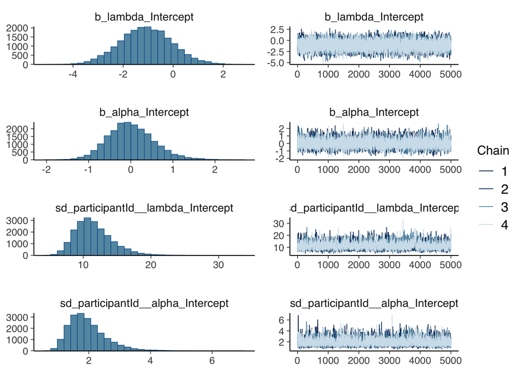

```r
plot(model.y.lomax)
```

Perform posterior predictive checks:

```r
expose_functions(model.y.lomax, vectorize = TRUE)

# Define the posterior_predict function in R as per the following vignette
# https://cran.r-project.org/web/packages/brms/vignettes/brms_customfamilies.html
posterior_predict_lomax <- function(i, draws, ...) {
  lambda <- draws$dpars$lambda[i]
  alpha <- draws$dpars$alpha[i]
  lomax_rng(0, lambda, alpha)
}

# define custom log likelihood function for loo comparison

log_lik_lomax <- function(i, prep) {
  mu <- brms::get_dpar(prep, "mu", i = i)
  lambda <- brms::get_dpar(prep, "lambda", i = i)
  alpha <- brms::get_dpar(prep, "alpha", i = i)
  y <- prep$data$Y[i]

  # Lomax log-density: log(alpha) - log(lambda) - (alpha+1) * log(1 + y/lambda)
  log(alpha) - log(lambda) - (alpha + 1) * log1p(y / lambda)
}
```

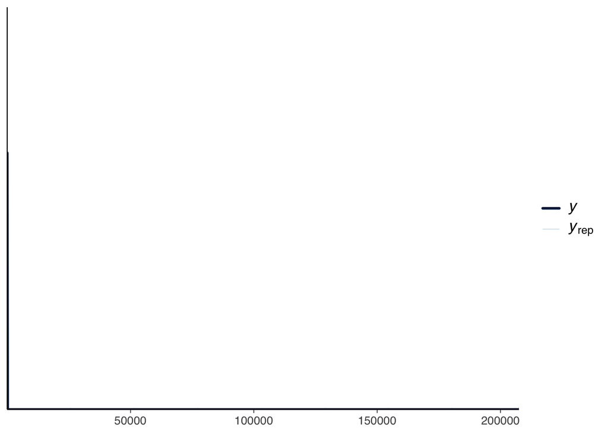

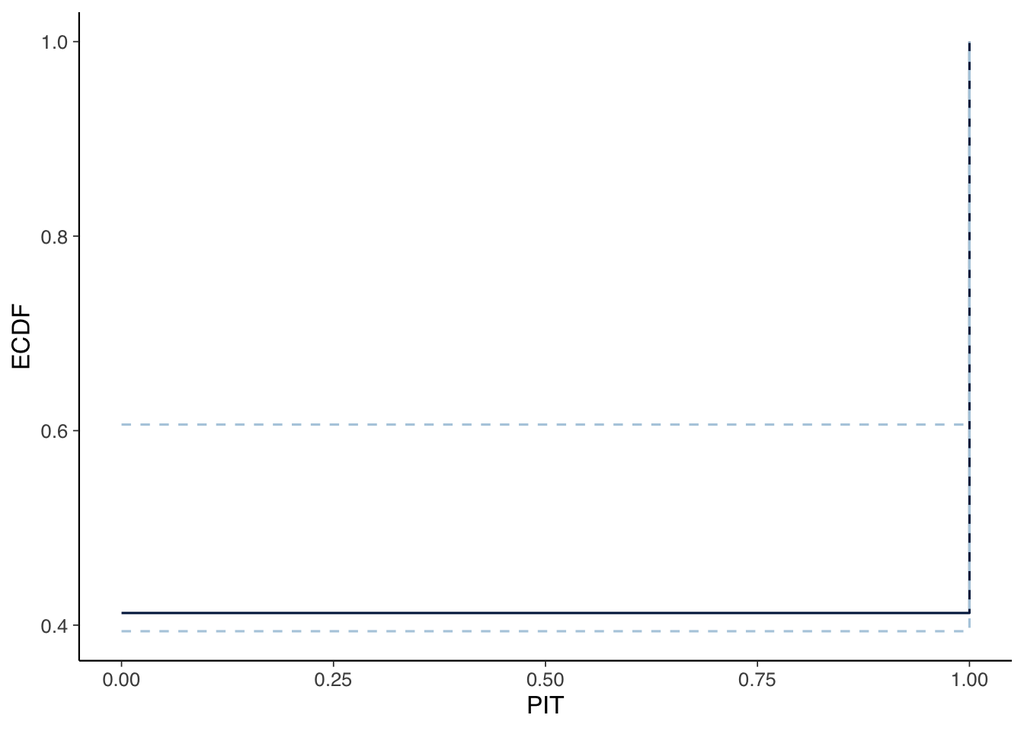

```r
pp_check(model.y.lomax, ndraws = 100)
pp_check(model.y.lomax, ndraws = 100, type = "pit_ecdf")
```

From the PIT-ECDF check it seems that indeed the lomax model is not a good one, because a well-calibrated model should show the line following the 45 degree line, not a flat line from above.

## Error on Y, Exponential Distribution

Formula and prior:

```r
f <- bf(
  error.y ~ 0,
  mu ~ (1 | participantId), # technically this is lambda but we call it mu nonetheless
  family = exponential
)

# mu has log-link, so we don't pose any bounds on it
p <- c(
  prior(normal(0, 1), class = Intercept),
  prior(cauchy(0, 1), class = sd, group = participantId, lb = 0)
)
```

Fit the model:

```r
model.y.exponential <- task2_df %>%
  mutate(error.y = abs(va.ans.y - va.resp.y)) %>%
  brm(
    formula = f,
    data = .,
    prior = p,
    chains = 4,
    cores = 4,
    file = here("analysis", "fitted_models", "part1", "task2.y.exponential"),
    file_refit = "on_change",
    control = list(adapt_delta = 0.99),
    iter = 6000,
    save_pars = save_pars(all = TRUE)
  )
```

Check fit and posterior:

```r
summary(model.y.exponential)
```

```
 Family: exponential
  Links: mu = log
Formula: error.y ~ 0
         mu ~ (1 | participantId)
   Data: . (Number of observations: 160)
  Draws: 4 chains, each with iter = 6000; warmup = 3000; thin = 1;
         total post-warmup draws = 12000

Multilevel Hyperparameters:
~participantId (Number of levels: 16)
              Estimate Est.Error l-95% CI u-95% CI Rhat Bulk_ESS Tail_ESS
sd(Intercept)     1.31      0.32     0.84     2.11 1.00     1779     2254

Regression Coefficients:
          Estimate Est.Error l-95% CI u-95% CI Rhat Bulk_ESS Tail_ESS
Intercept    -4.38      0.39    -5.04    -3.49 1.00     1303     1607

Draws were sampled using sample(hmc). For each parameter, Bulk_ESS
and Tail_ESS are effective sample size measures, and Rhat is the potential
scale reduction factor on split chains (at convergence, Rhat = 1).
```

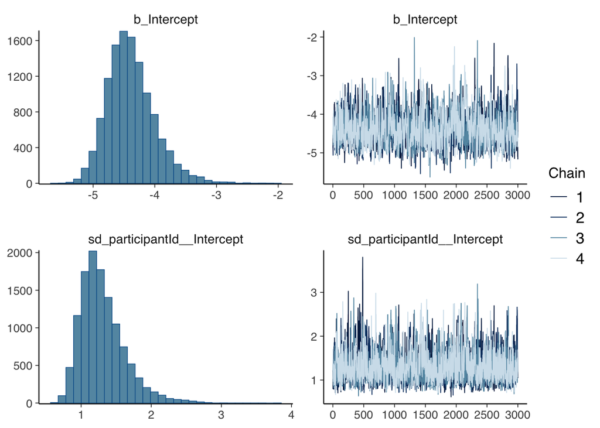

```r
plot(model.y.exponential)
```

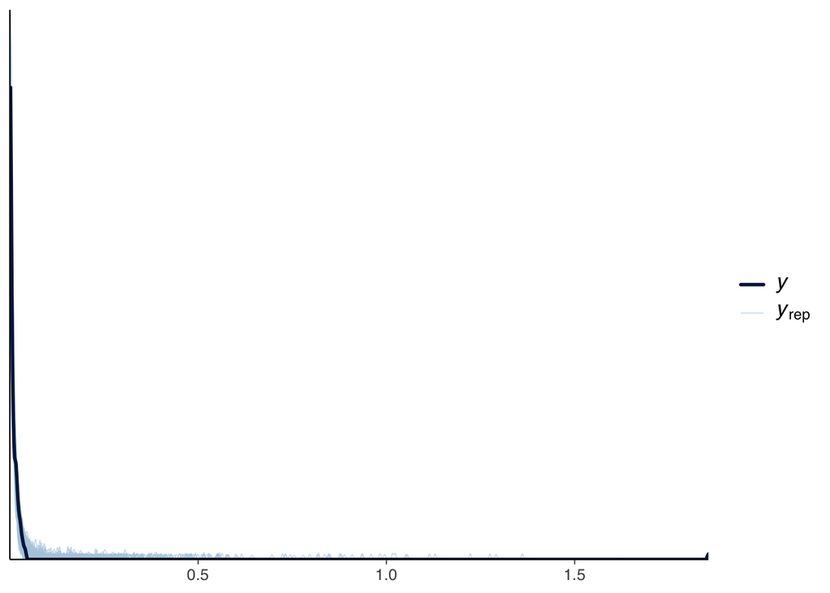

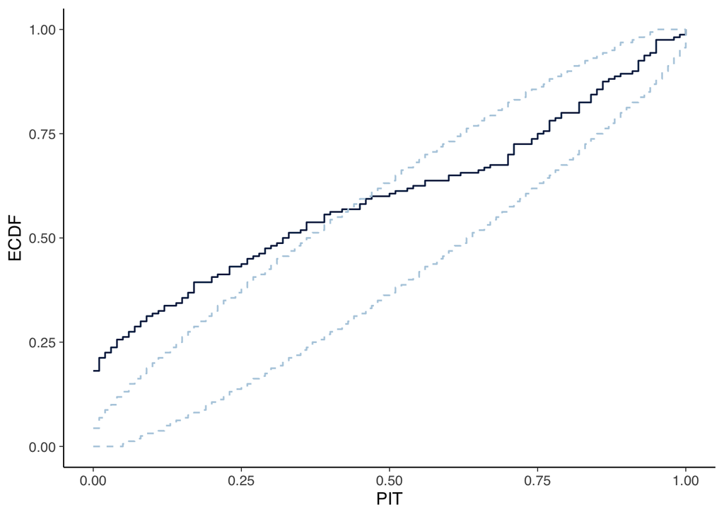

```r
pp_check(model.y.exponential, ndraws = 100)
pp_check(model.y.exponential, ndraws = 100, type = "pit_ecdf")
```

The KDE density overlay looks more reasonable, but the PIT-ECDF chart tells us that’s it not quite well-calibrated.

## Error on Y, Weibull

Math formula:

$$\begin{align}
\texttt{error}_i &\sim \text{Weibull}(\mu_{\text{PID}[i]}, k_{\text{PID}[i]}) \\
\log(\mu_j) &= \alpha_j \\
\log(k_j) &= \beta_j \\
\alpha_j &\sim \mathcal{N}(\mu_\alpha, \sigma_\alpha) \\
\beta_j &\sim \mathcal{N}(\mu_\beta, \sigma_\beta) \\
\mu_\alpha, \mu_\beta &\sim \mathcal{N}(0, 1) \\
\sigma_\alpha, \sigma_beta &\sim \mathcal{N}^+(0, 1)
\end{align}$$

Specify formula and prior:

```r
f <- bf(
  error.y ~ 0,
  mu ~ (1 | participantId), # log link
  shape ~ (1 | participantId), # log link
  family = weibull()
)

p <- c(
  prior(normal(0, 1), class = Intercept),
  prior(normal(0, 1), class = sd, group = participantId, lb = 0),
  prior(normal(0, 1), class = Intercept, dpar = shape),
  prior(normal(0, 1), class = sd, group = participantId, dpar = shape, lb = 0)
)
```

Fit the model:

```r
model.y.weibull <- task2_df %>%
  mutate(error.y = va.ans.y - va.resp.y) %>%
  mutate(error.y = ifelse(error.y < tolerance, tolerance, error.y)) %>% # Weibull needs value to be > 0
  brm(
    formula = f,
    data = .,
    prior = p,
    chains = 4,
    cores = 4,
    file = here("analysis", "fitted_models", "part1", "task2.y.weibull"),
    file_refit = "on_change",
    save_pars = save_pars(all = TRUE),
    control = list(adapt_delta = 0.99),
    iter = 6000
  )
```

Check fit and posterior:

```r
summary(model.y.weibull)
```

```
 Family: weibull
  Links: mu = log; shape = log
Formula: error.y ~ 0
         mu ~ (1 | participantId)
         shape ~ (1 | participantId)
   Data: . (Number of observations: 160)
  Draws: 4 chains, each with iter = 6000; warmup = 3000; thin = 1;
         total post-warmup draws = 12000

Multilevel Hyperparameters:
~participantId (Number of levels: 16)
                    Estimate Est.Error l-95% CI u-95% CI Rhat Bulk_ESS Tail_ESS
sd(Intercept)           0.32      0.25     0.01     0.93 1.00     3284     5407
sd(shape_Intercept)     0.44      0.12     0.25     0.71 1.00     3305     5387

Regression Coefficients:
                Estimate Est.Error l-95% CI u-95% CI Rhat Bulk_ESS Tail_ESS
Intercept          -4.25      0.24    -4.68    -3.73 1.00     7107     5716
shape_Intercept    -0.83      0.13    -1.09    -0.56 1.00     4068     6035

Draws were sampled using sample(hmc). For each parameter, Bulk_ESS
and Tail_ESS are effective sample size measures, and Rhat is the potential
scale reduction factor on split chains (at convergence, Rhat = 1).
```

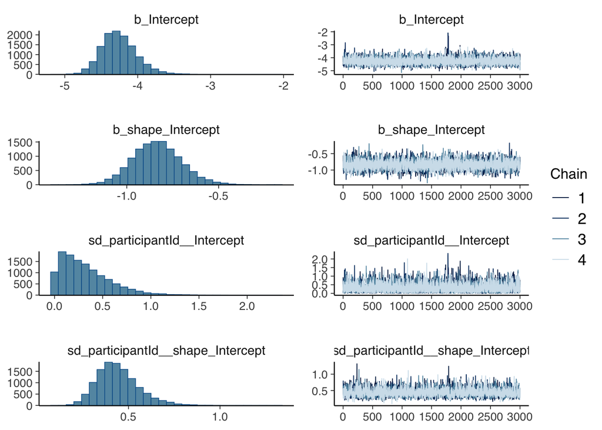

```r
plot(model.y.weibull)
```

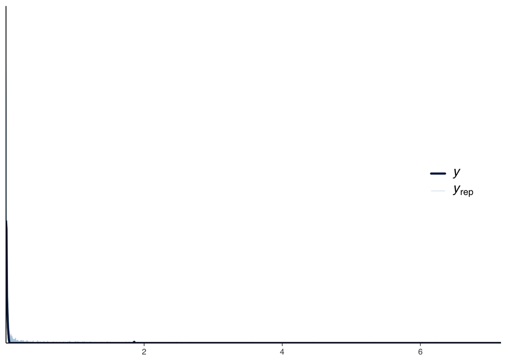

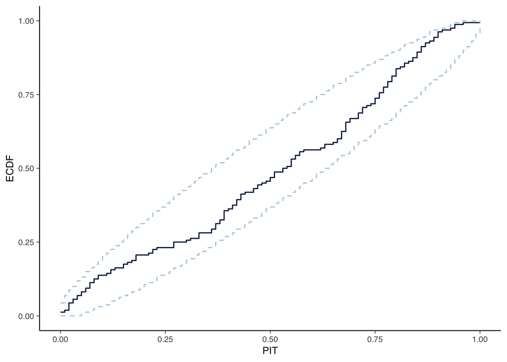

```r
pp_check(model.y.weibull, ndraws = 100) +
  theme(legend.position = c(0.9, 0.5)) +
  theme(text = element_text(size = 10)) -> p1

pp_check(model.y.weibull, ndraws = 100, type = "pit_ecdf") +
  theme(text = element_text(size = 10)) -> p2

p1
p2
```

Posterior retrodictive plot:

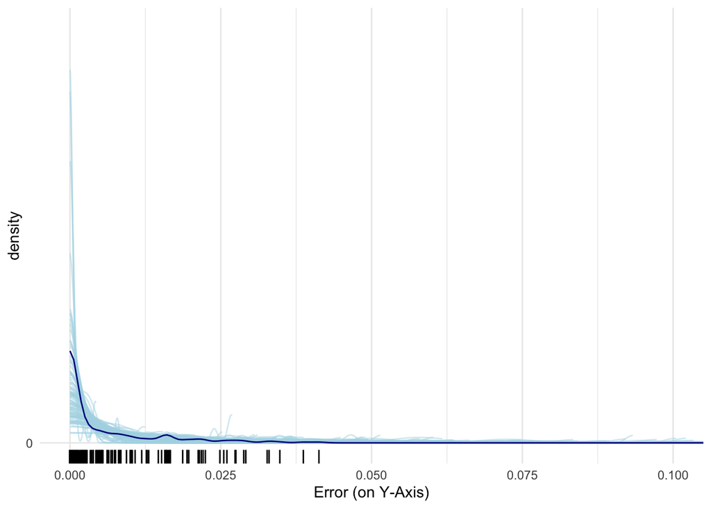

```r
task2_df %>%
  modelr::data_grid(error.y = 0, participantId = unique(participantId)) %>%
  add_predicted_draws(model.y.weibull, ndraws = 100) %>%
  # group_by(.draw) %>%
  ggplot() +
  stat_slab(
    aes(x = .prediction, group = .draw),
    color = "lightblue",
    alpha = 0.5,
    fill = NA,
    n = 3000,
    size = 0.5
  ) +
  scale_thickness_shared() +
  coord_cartesian(xlim = c(0, 0.1)) +
  geom_rug(data = task2_df, aes(x = va.ans.y - va.resp.y), linewidth = 0.5) +
  stat_slab(
    data = task2_df,
    aes(x = va.ans.y - va.resp.y),
    color = "darkblue",
    fill = NA,
    n = 3000,
    size = 0.5
  ) +
  labs(y = "density", x = "Error (on Y-Axis)") +
  scale_y_continuous(breaks = 0) -> p

p
```

## Error on Y, Log-Normal

Math formula:
$$\begin{align*}
\texttt{error.y}_i &\sim \text{Log-Normal}(\mu_{\text{PID}[i]},\ \sigma_{\text{PID}[i]}) \\
\mu_j &= \alpha_j \\
\log(\sigma_j) &= \beta_j \\
\alpha_j &\sim \mathcal{N}(\mu_\alpha,\ \tau_\alpha) \\
\beta_j &\sim \mathcal{N}(\mu_\beta,\ \tau_\beta) \\
\mu_\alpha,\ \mu_\beta &\sim \mathcal{N}(0, 1) \\
\tau_\alpha,\ \tau_\beta &\sim \mathcal{N}^{+}(0, 1)
\end{align*}$$

Specify formula and prior:

```r
f <- bf(
  error.y ~ 0,
  mu ~ (1 | participantId),
  sigma ~ (1 | participantId),
  family = lognormal()
)

p <- c(
  prior(normal(0, 1), class = Intercept),
  prior(normal(0, 1), class = sd, group = participantId, lb = 0),
  prior(normal(0, 1), class = Intercept, dpar = sigma),
  prior(normal(0, 1), class = sd, group = participantId, dpar = sigma, lb = 0)
)
```

```r
model.y.lognormal <- task2_df %>%
  mutate(error.y = va.ans.y - va.resp.y) %>%
  mutate(error.y = ifelse(error.y < tolerance, tolerance, error.y)) %>%
  brm(
    formula = f,
    data = .,
    prior = p,
    chains = 4,
    cores = 4,
    file = here("analysis", "fitted_models", "part1", "task2.y.lognormal"),
    file_refit = "on_change",
    save_pars = save_pars(all = TRUE),
    control = list(adapt_delta = 0.99),
    iter = 6000
  )
```

Check fit and posterior:

```r
summary(model.y.lognormal)
```

```
 Family: lognormal
  Links: mu = identity; sigma = log
Formula: error.y ~ 0
         mu ~ (1 | participantId)
         sigma ~ (1 | participantId)
   Data: . (Number of observations: 160)
  Draws: 4 chains, each with iter = 6000; warmup = 3000; thin = 1;
         total post-warmup draws = 12000

Multilevel Hyperparameters:
~participantId (Number of levels: 16)
                    Estimate Est.Error l-95% CI u-95% CI Rhat Bulk_ESS Tail_ESS
sd(Intercept)           1.14      0.57     0.17     2.43 1.00     2056     3282
sd(sigma_Intercept)     0.59      0.14     0.37     0.90 1.00     3501     5843

Regression Coefficients:
                Estimate Est.Error l-95% CI u-95% CI Rhat Bulk_ESS Tail_ESS
Intercept          -5.67      0.49    -6.45    -4.47 1.00     3343     3332
sigma_Intercept     1.24      0.17     0.92     1.57 1.00     2640     4993

Draws were sampled using sample(hmc). For each parameter, Bulk_ESS
and Tail_ESS are effective sample size measures, and Rhat is the potential
scale reduction factor on split chains (at convergence, Rhat = 1).
```

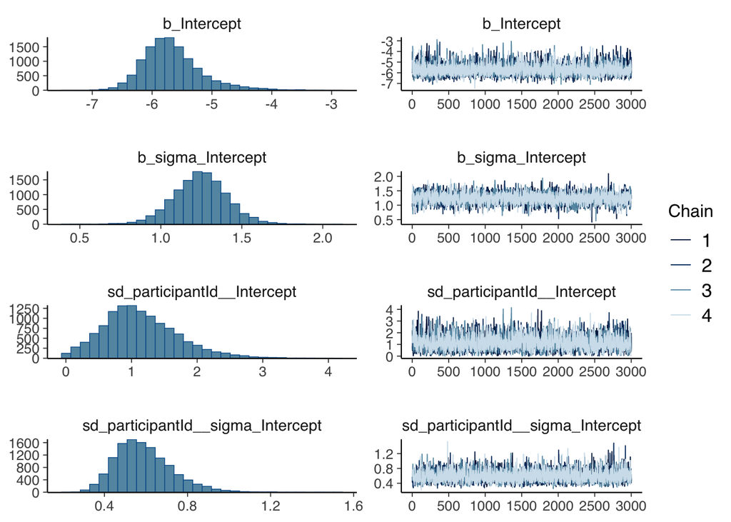

```r
plot(model.y.lognormal)
```

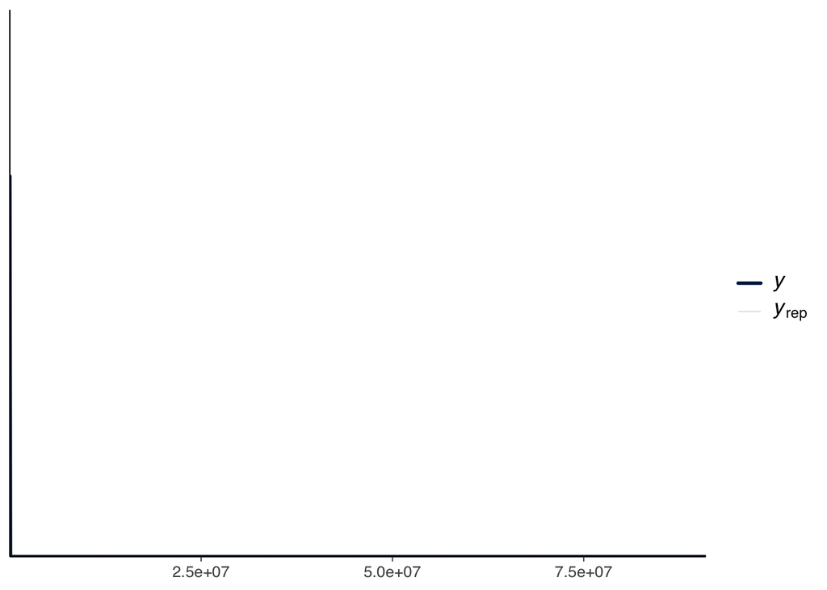

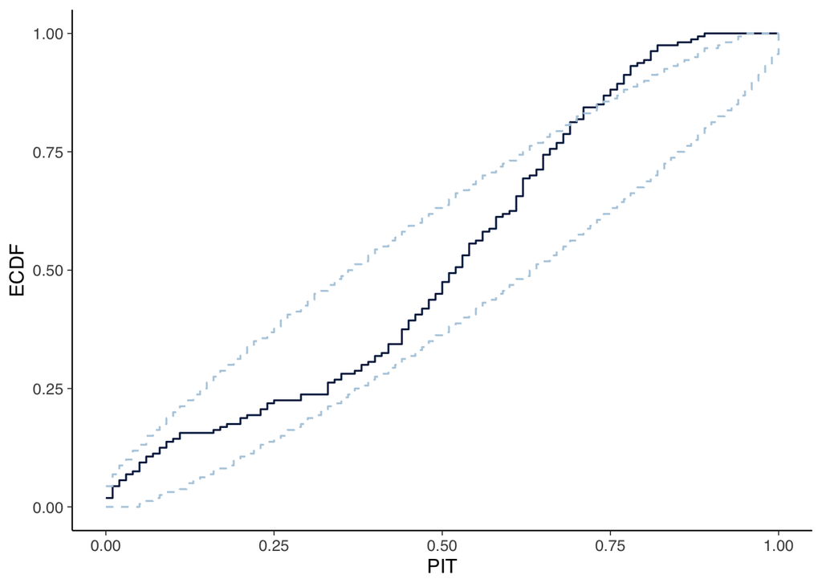

```r
pp_check(model.y.lognormal, ndraws = 100)
pp_check(model.y.lognormal, ndraws = 100, type = "pit_ecdf")
```

## Error on Y, Gamma

Math formula:

$$\begin{align*}
\texttt{error.y}_i &\sim \text{Gamma}(\mu_{\text{PID}[i]},\ k_{\text{PID}[i]}) \\
\mu_j &= \alpha_j^{-1} \\
\log(k_j) &= \beta_j \\
\alpha_j &\sim \mathcal{N}(\mu_\alpha,\ \tau_\alpha) \\
\beta_j &\sim \mathcal{N}(\mu_\beta,\ \tau_\beta) \\
\mu_\alpha,\ \mu_\beta &\sim \mathcal{N}(0, 1) \\
\tau_\alpha,\ \tau_\beta &\sim \mathcal{N}^{+}(0, 1)
\end{align*}$$

Specify formula and prior:

```r
f <- bf(
  error.y ~ 0,
  mu ~ (1 | participantId),
  shape ~ (1 | participantId),
  family = Gamma()
)

p <- c(
  prior(normal(0, 1), class = Intercept),
  prior(normal(0, 1), class = sd, group = participantId, lb = 0),
  prior(normal(0, 1), class = Intercept, dpar = shape),
  prior(normal(0, 1), class = sd, group = participantId, dpar = shape, lb = 0)
)
```

```r
model.y.gamma <- task2_df %>%
  mutate(error.y = va.ans.y - va.resp.y) %>%
  mutate(error.y = ifelse(error.y < tolerance, tolerance, error.y)) %>%
  brm(
    formula = f,
    data = .,
    prior = p,
    chains = 4,
    cores = 4,
    file = here("analysis", "fitted_models", "part1", "task2.y.gamma"),
    file_refit = "on_change",
    save_pars = save_pars(all = TRUE),
    control = list(adapt_delta = 0.99),
    iter = 6000
  )
```

Note that the above have a lot of divergent transitions, even though we took `adapt_delta = 0.99`, suggesting that this is a bad posterior fit, and that this is not the right model.

Nevertheless, we check its posterior fit for completeness:

```r
summary(model.y.gamma)
```

```
 Family: gamma
  Links: mu = inverse; shape = log
Formula: error.y ~ 0
         mu ~ (1 | participantId)
         shape ~ (1 | participantId)
   Data: . (Number of observations: 160)
  Draws: 4 chains, each with iter = 6000; warmup = 3000; thin = 1;
         total post-warmup draws = 12000

Multilevel Hyperparameters:
~participantId (Number of levels: 16)
                    Estimate Est.Error l-95% CI u-95% CI Rhat Bulk_ESS Tail_ESS
sd(Intercept)           1.30      1.00     0.04     3.73 1.00     4592     4882
sd(shape_Intercept)     0.17      0.12     0.01     0.44 1.00     4176     5956

Regression Coefficients:
                Estimate Est.Error l-95% CI u-95% CI Rhat Bulk_ESS Tail_ESS
Intercept           4.80      0.78     3.27     6.36 1.00    11949     8333
shape_Intercept    -1.80      0.10    -2.00    -1.59 1.00    10587     8225

Draws were sampled using sample(hmc). For each parameter, Bulk_ESS
and Tail_ESS are effective sample size measures, and Rhat is the potential
scale reduction factor on split chains (at convergence, Rhat = 1).
```

Checking the PIT-ECDF plot to confirm that the posterior fit is bad:

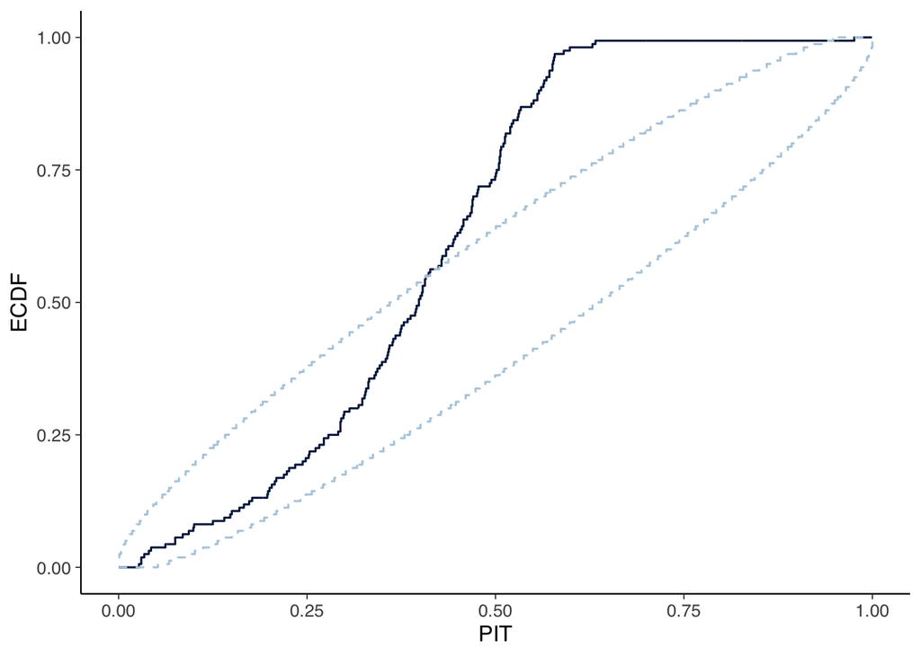

```r
pp_check(model.y.gamma, type = "pit_ecdf")
```

## LOO Comparison

Note that we won’t use Gamma in the model comparison, because the models have divergent transitions after fitting and demonstrate poor calibration.

Loo comparison:

```r
brms::loo(
  model.y.lomax,
  model.y.exponential,
  model.y.lognormal,
  model.y.weibull,
  moment_match = TRUE,
  reloo = FALSE,
  cores = parallel::detectCores()
)
```

```
Output of model 'model.y.lomax':

Computed from 20000 by 160 log-likelihood matrix.

         Estimate   SE
elpd_loo    685.5 40.8
p_loo       112.3 30.5
looic     -1371.0 81.7
------
MCSE of elpd_loo is NA.
MCSE and ESS estimates assume MCMC draws (r_eff in [0.0, 1.1]).

Pareto k diagnostic values:
                         Count Pct.    Min. ESS
(-Inf, 0.7]   (good)     151   94.4%   88
   (0.7, 1]   (bad)        3    1.9%   <NA>
   (1, Inf)   (very bad)   6    3.8%   <NA>
See help('pareto-k-diagnostic') for details.

Output of model 'model.y.exponential':

Computed from 12000 by 160 log-likelihood matrix.

         Estimate   SE
elpd_loo    577.7 47.4
p_loo        56.4 32.3
looic     -1155.5 94.8
------
MCSE of elpd_loo is NA.
MCSE and ESS estimates assume MCMC draws (r_eff in [0.4, 1.7]).

Pareto k diagnostic values:
                         Count Pct.    Min. ESS
(-Inf, 0.7]   (good)     159   99.4%   1079
   (0.7, 1]   (bad)        1    0.6%   <NA>
   (1, Inf)   (very bad)   0    0.0%   <NA>
See help('pareto-k-diagnostic') for details.

Output of model 'model.y.lognormal':

```

[output cut: 23 more lines]

```
p_loo        25.8  5.7
looic     -1510.3 86.4
------
MCSE of elpd_loo is NaN.
MCSE and ESS estimates assume MCMC draws (r_eff in [0.5, 1.5]).

All Pareto k estimates are good (k < 0.7).
See help('pareto-k-diagnostic') for details.

Model comparisons:
                    elpd_diff se_diff
model.y.weibull        0.0       0.0
model.y.lognormal    -46.5       8.0
model.y.lomax        -69.7      16.5
model.y.exponential -177.4      46.7
```

Weibull is the best model.

# Error on X, Normal distribution

Math model:

$$\begin{align}
\texttt{error\_va}_{i} &\sim \text{Normal}(\mu_\text{PID[i]}, \sigma_{\text{PID[i]}}^2) \\
\mu_j &\sim \mathcal{N}(\bar{\mu}, \bar{\sigma}^2), j \in [16] \\
\sigma_j &\sim \mathcal{N}^+(\alpha, \beta^2), j \in [16] \\
\bar{\mu}, \alpha &\sim \mathcal{N}(0, 1)\\
\bar{\sigma}, \beta &\sim \mathcal{N}^+(0, 1)
\end{align}$$

Formula and prior:

```r
f <- bf(
  error.x ~ 0,
  mu ~ (1 | participantId),
  sigma ~ (1 | participantId),
  family = gaussian
)

# sigma has log-link, so we don't pose any bounds on it
p <- c(
  prior(normal(0, 1), class = Intercept),
  prior(normal(0, 1), class = sd, group = participantId, lb = 0),
  prior(normal(0, 1), class = Intercept, dpar = sigma),
  prior(normal(0, 1), class = sd, group = participantId, dpar = sigma, lb = 0)
)
```

Fit the model:

```r
model.x.normal <- task2_df %>%
  mutate(error.x = va.resp.x - va.ans.x) %>%
  brm(
    formula = f,
    data = .,
    prior = p,
    chains = 4,
    cores = 4,
    file = here("analysis", "fitted_models", "part1", "task2.x.normal"),
    file_refit = "on_change",
    control = list(adapt_delta = 0.99),
    iter = 6000,
    save_pars = save_pars(all = TRUE)
  )
```

Check fit and posterior:

```r
summary(model.x.normal)
```

```
 Family: gaussian
  Links: mu = identity; sigma = log
Formula: error.x ~ 0
         mu ~ (1 | participantId)
         sigma ~ (1 | participantId)
   Data: . (Number of observations: 160)
  Draws: 4 chains, each with iter = 6000; warmup = 3000; thin = 1;
         total post-warmup draws = 12000

Multilevel Hyperparameters:
~participantId (Number of levels: 16)
                    Estimate Est.Error l-95% CI u-95% CI Rhat Bulk_ESS Tail_ESS
sd(Intercept)           0.04      0.03     0.00     0.11 1.00     3737     5412
sd(sigma_Intercept)     0.33      0.11     0.15     0.57 1.00     3880     4475

Regression Coefficients:
                Estimate Est.Error l-95% CI u-95% CI Rhat Bulk_ESS Tail_ESS
Intercept           0.01      0.02    -0.03     0.06 1.00    10139     8368
sigma_Intercept    -1.37      0.11    -1.58    -1.16 1.00     5211     7137

Draws were sampled using sample(hmc). For each parameter, Bulk_ESS
and Tail_ESS are effective sample size measures, and Rhat is the potential
scale reduction factor on split chains (at convergence, Rhat = 1).
```

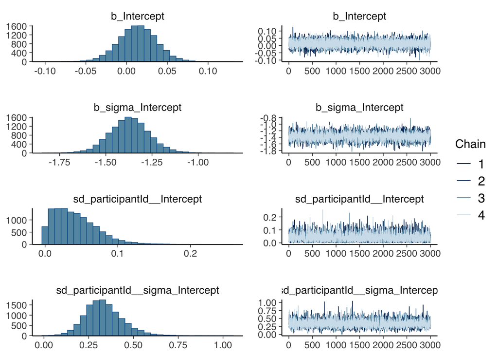

```r
plot(model.x.normal)
```

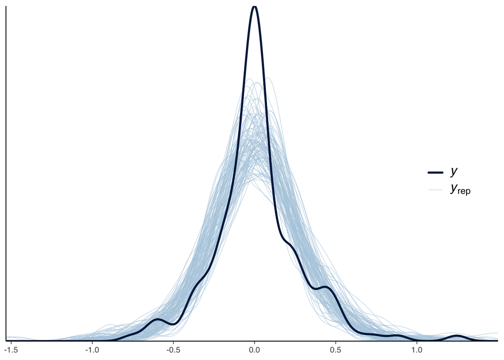

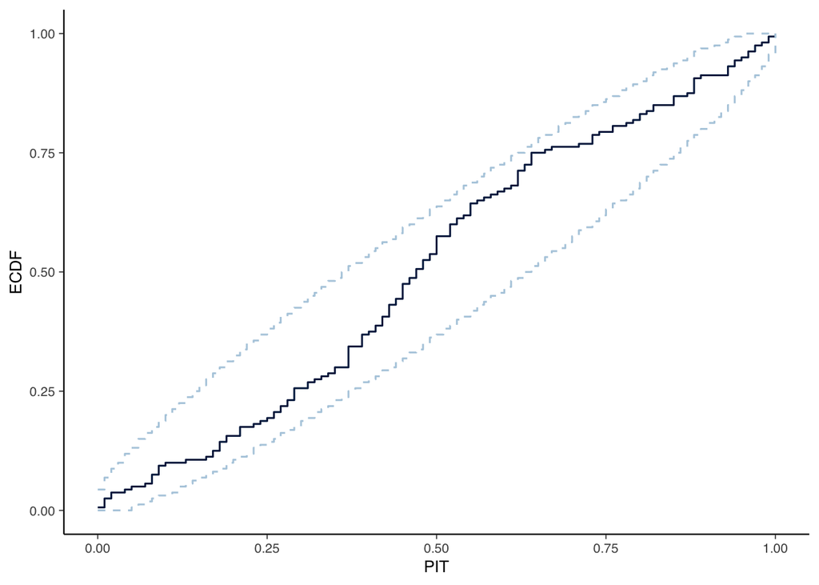

```r
pp_check(model.x.normal, ndraws = 100) +
  theme(legend.position = c(0.9, 0.5)) +
  theme(text = element_text(size = 10)) -> task2.x.gaussian

pp_check(model.x.normal, ndraws = 100, type = "pit_ecdf") +
  theme(text = element_text(size = 10)) -> task2.x.gaussian.pit

task2.x.gaussian
task2.x.gaussian.pit
```

**Important**

Get the posterior for fitting another operator (i.e., `BisectArea`):

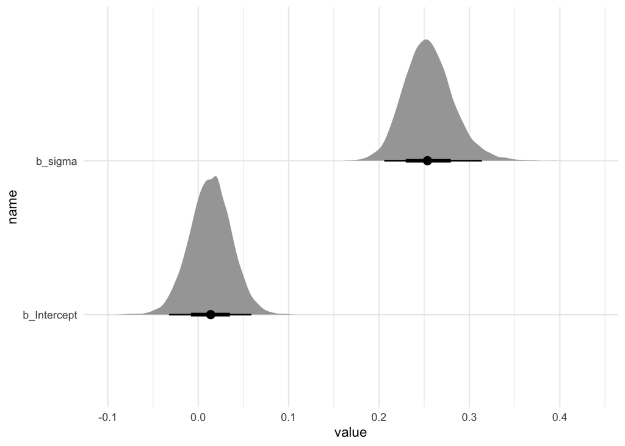

```r
# model.x.normal %>% get_variables(.)

model.x.normal %>%
  spread_draws(b_Intercept, b_sigma_Intercept) %>%
  mutate(b_sigma = exp(b_sigma_Intercept)) %>%
  pivot_longer(cols = c(b_Intercept, b_sigma)) %>%
  ggplot(aes(x = value, y = name)) +
  stat_halfeye()
```

```r
model.x.normal %>%
  spread_draws(b_Intercept, b_sigma_Intercept) %>%
  mutate(b_sigma = exp(b_sigma_Intercept)) %>%
  pivot_longer(cols = c(b_Intercept, b_sigma)) %>%
  group_by(name) %>%
  median_qi(value, .width = c(0.66, 0.95))
```

| name | value | .lower | .upper | .width | .point | .interval |
| --- | --- | --- | --- | --- | --- | --- |
| b_Intercept | 0.0137619 | -0.008038497 | 0.03515885 | 0.66 | median | qi |
| b_sigma | 0.2535718 | 0.229590940 | 0.27941523 | 0.66 | median | qi |
| b_Intercept | 0.0137619 | -0.032293558 | 0.05883677 | 0.95 | median | qi |
| b_sigma | 0.2535718 | 0.205794751 | 0.31377800 | 0.95 | median | qi |

# From error on Y to error on X

Create a dataframe for the “average participant”:

```r
avg_pixelToMM <- participants %>% pull(pixelToMM) %>% mean(.)
avg_distToScreen <- participants %>% pull(dist_to_screen) %>% mean(.)
avg_participant <- tibble(
  pixelToMM = avg_pixelToMM,
  distToScreen = avg_distToScreen,
  participantId = "avg_participant"
)

avg_participant
```

| pixelToMM | distToScreen | participantId |
| --- | --- | --- |
| 5.135294 | 574.7748 | avg_participant |

Create dataframe for average participant and do posterior draws:

```r
# Y-error draws in visual angle space
y_draws <- avg_participant %>%
  add_predicted_draws(
    model.y.weibull,
    re_formula = NULL, # include random effects
    allow_new_levels = TRUE,
    seed = 1
  )
```

# Plot the marginalized example to use for paper

So here are the parameters of the particular example we’re looking at: $\mu = -1.1, \sigma = 0.9, \lambda = -0.3, p = 2.6, q = 2.17$. The highest point has x coordinate `-1.1` and y coordinate `dsgt(-1.1, ...)`.

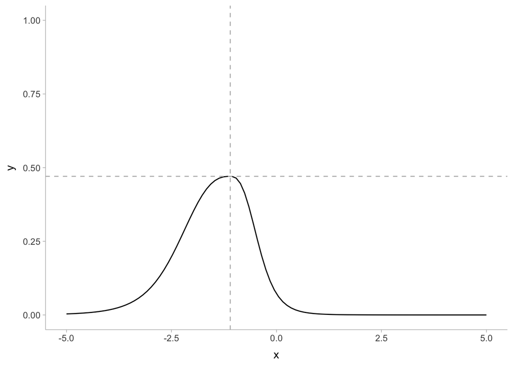

```r
x <- seq(-5, 5, length.out = 100)
y <- dsgt(
  x,
  mu = -1.1,
  sigma = 0.9,
  lambda = -0.3,
  p = 2.6,
  q = 2.17,
  mean.cent = FALSE
)

x_val = -1.1
y_val = dsgt(
  x_val,
  mu = -1.1,
  sigma = 0.9,
  lambda = -0.3,
  p = 2.6,
  q = 2.17,
  mean.cent = FALSE
)

example_plot <- tibble(x = x, y = y) %>%
  ggplot(aes(x = x, y = y)) +
  geom_line() +
  coord_cartesian(xlim = c(-5, 5), ylim = c(0, 1)) +
  theme_tidybayes() +
  geom_vline(xintercept = x_val, linetype = "dashed", color = "gray") +
  geom_hline(
    yintercept = y_val,
    linetype = "dashed",
    color = "gray"
  )
example_plot
```

```r
# specific pdf we're working with
f <- function(x) {
  dsgt(
    x,
    mu = -1.1,
    sigma = 0.9,
    lambda = -0.3,
    p = 2.6,
    q = 2.17,
    mean.cent = FALSE
  )
}

va.ans.y <- exp1_y$data_to_va(y_val, avg_distToScreen, avg_pixelToMM)

# here we go from errors on y to errors on x
x_errors <- y_draws %>%
  mutate(
    va.pred.y = va.ans.y - .prediction,
    num.pred.y = exp1_y$va_to_data(va.pred.y, avg_distToScreen, avg_pixelToMM),
    eps_data = y_val - num.pred.y
  ) %>%
  rowwise() %>%
  mutate(
    x_left = uniroot(function(x) f(x) - num.pred.y, c(-5, x_val))$root,
    x_right = uniroot(function(x) f(x) - num.pred.y, c(x_val, 5))$root,
    # random flip betwee x_left and x_right
    num.pred.x = if (sample(c(TRUE, FALSE), 1)) x_left else x_right
  )
```

So we will use this plot as our example for things to marginalize.

```r
theme_set(theme_tidybayes(base_size = 10))

x_graph <- x_errors %>%
  ggplot(aes(x = num.pred.x)) +
  stat_slab() +
  coord_cartesian(xlim = c(-5, 5)) +
  scale_y_continuous(breaks = 0) +
  labs(x = "", y = "density")

y_graph <- x_errors %>%
  ggplot(aes(y = num.pred.y)) +
  stat_slab() +
  coord_cartesian(ylim = c(0, 1)) +
  scale_x_continuous(breaks = 0) +
  labs(x = "density", y = "")
```

Use patchwork to put things together:

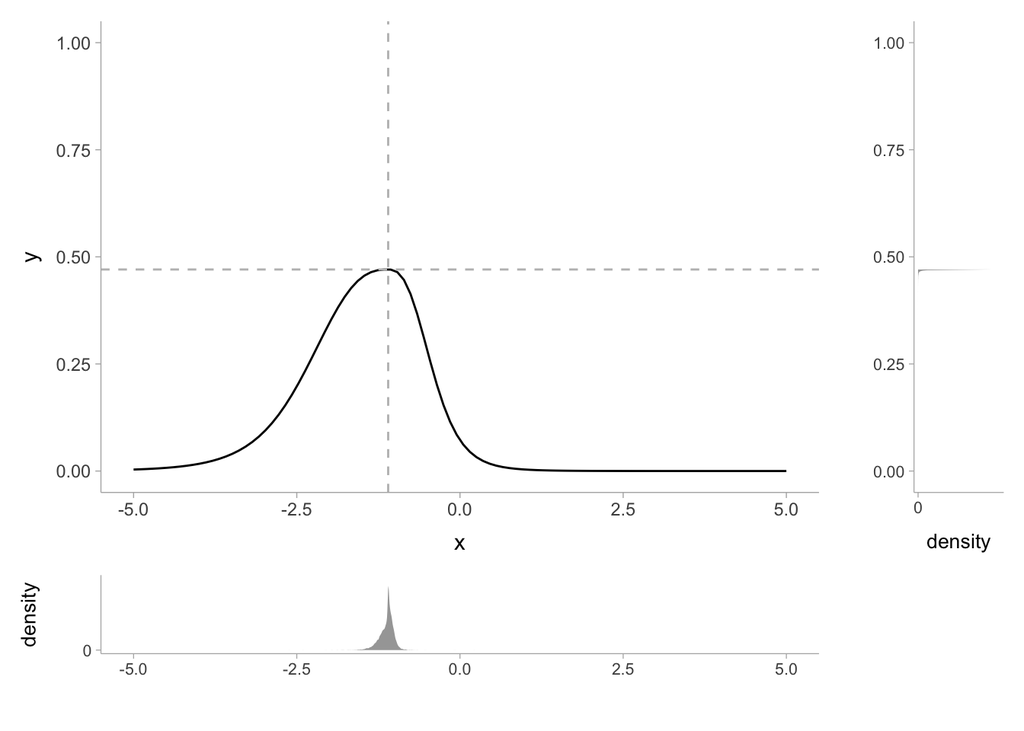

```r
library(patchwork)

new_output <- example_plot +
  y_graph +
  x_graph +
  plot_spacer() +
  plot_layout(
    ncol = 2,
    nrow = 2,
    widths = c(4, 0.5),
    heights = c(3, 0.5)
  )

new_output
```

Error on y is too hard to see, so we also create a zoomed-in version of it:

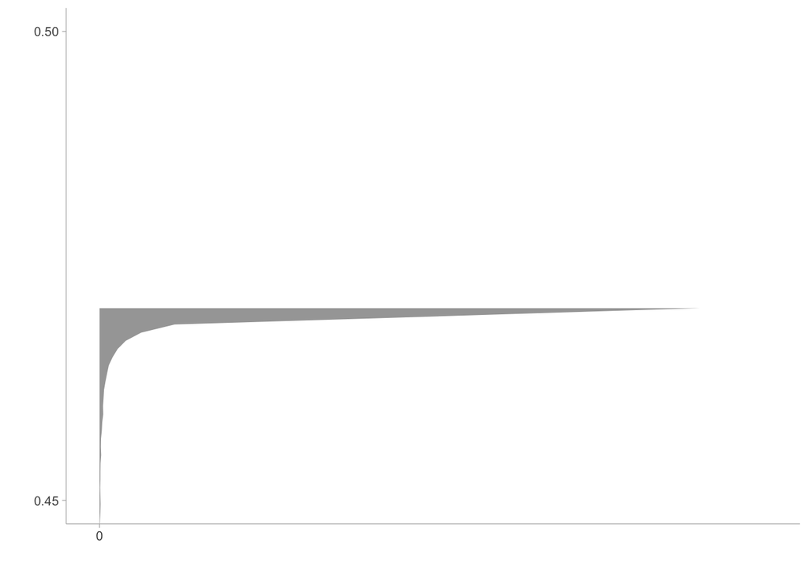

```r
y_zoom <- y_graph +
  coord_cartesian(ylim = c(0.45, 0.5)) +
  labs(x = "") +
  # theme_tidybayes(base_size = 6) +
  scale_y_continuous(breaks = c(0.45, 0.50))

y_zoom
```